# Eksperyment dotyczący wykresów

## Opis eksperymentu

Zbadamy jak typ wykresu wpływa na odbiór danych w przypadku, w którym odbiorca nie ma podanych wartości liczbowych.

## Jak go przeprowadzimy?

Punktem wyjścia będzie dla nas ten oto wykres:

[figure not shown]

Wybierzmy arbitralnie jedną z grup wiekowych, niech będzie to grupa 50 - 59 lat. Zobaczymy jak dobrze ludzie są w stanie oszacować wartości, które nie są podane wprost jako liczby i czy wyniki będą inne na wykresie

## Jaki jest problem?

Jeżeli po prostu weźmiemy dane i przedstawimy je na wykresie kołowym prosząc o oszacowanie wartości, to respondenci szybko zorientują się, że to te same dane co może zaburzyć wyniki.

## Rozwiązanie

Przedstawimy te same dane, ale nazwiemy je zupełnie inaczej. Przedstawimy je jako owoce które najchętniej kupowali mieszkańcy Bytomia. Zmienimy kolory wykresu, tak żeby bardziej pasowały do owoców które reprezentują. W efekcie dostajemy taki oto wykres:

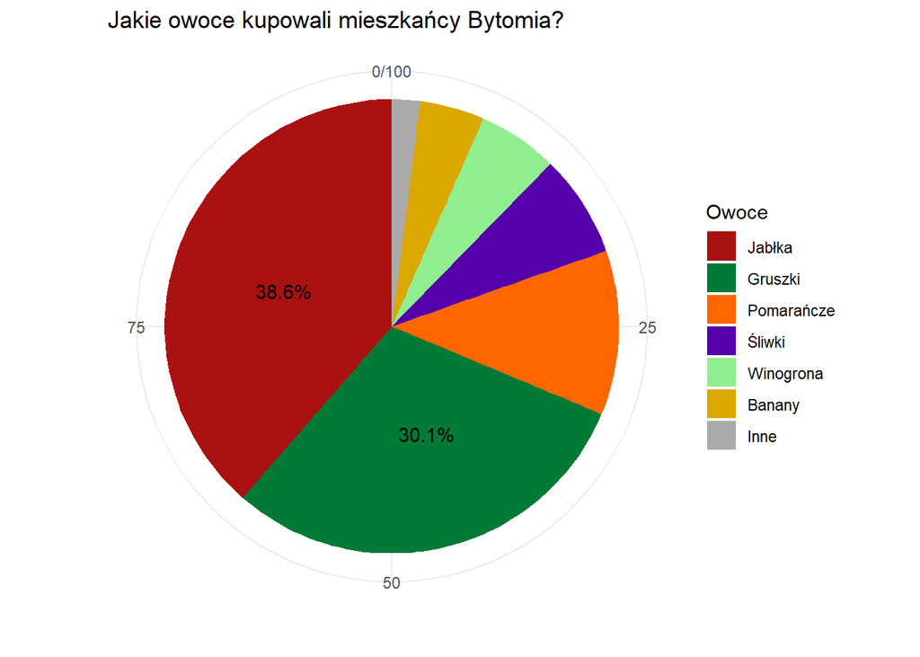

```r
# wczytanie bibliotek
library("ggplot2")
library("dplyr")

# sa to dane liczbowe poparcia roznych partii politycznych
# w lutym 2023 w grupie wiekowej 50 - 59
# sondaz IBSP
data <- data.frame(
  nazwy = c("Jabłka", "Gruszki", "Pomarańcze", "Banany", "Śliwki", "Winogrona", "Inne"),
  poparcie = c(38.6, 30.1, 11.7, 4.6, 7.3, 5.7, 2)
  )

# generowanie wykresu do ankiety
data %>%
  mutate(nazwy = forcats::fct_reorder(nazwy, poparcie, .desc = TRUE)) %>%
  ggplot( aes(x="", y=poparcie, fill = nazwy, label = nazwy)) +
  geom_bar(stat="identity", width=1) +
  coord_polar("y", start=0) +
  theme_minimal() +
  scale_fill_manual(values=c("#AA1111",
                             "#007A36",
                             "#FF6600",
                             "#5500AA",
                             "#90EE90",
                             "#DBA800",
                             "#AAAAAA"
                             )) +
  labs(x = "", y = "", fill = "Owoce") +
  ggtitle("Jakie owoce kupowali mieszkańcy Bytomia?") +
  annotate(geom="text", x=1, y=45, label="30.1%", color="#000000") +
  annotate(geom="text", x=1, y=80, label="38.6%", color="#000000")
```

Oczywiście są to te same dane co prognozowane poparcie dla różnych partii według sondażu IBSP w lutym 2023 w grupie wiekowej 50 - 59 lat. Widzimy też jakim partiom odpowiadają jakie owoce i tak np PiS to jabłka, KO to gruszki, POLSKA2050 to pomarańcze itd.

## Jak przeprowadzono ankietę?

W ankiecie zapytamy o poparcie dla partii POLSKA2050 w grupie wiekowej 50 - 59 lat, a także o udział pomarańczy we wszystkich owocach kupionych przez mieszkańców Bytomia. Podkreślmy, to jest dokładnie ta sama wartość która wynosi dokładnie 11.7%. W celu ukrycia faktu że pytamy dwa razy o to samo zadamy jeszcze kilka dodatkowych pytań, których jedynym zadaniem jest odciągnięcie uwagi respondentów. Ankietę można zobaczyć [tutaj](https://forms.office.com/r/fxSP4CC6SD).

## Wyniki

Anketę wypełniło łącznie 15 osób, spośród których żadna nie wiedziała czego będzie dotyczył eksperyment. Jak widzimy jedyne interesujące nas odpowiedzi dotyczą pytań 2 i 7. Na wykresie poniżej przedstawiono wyniki:

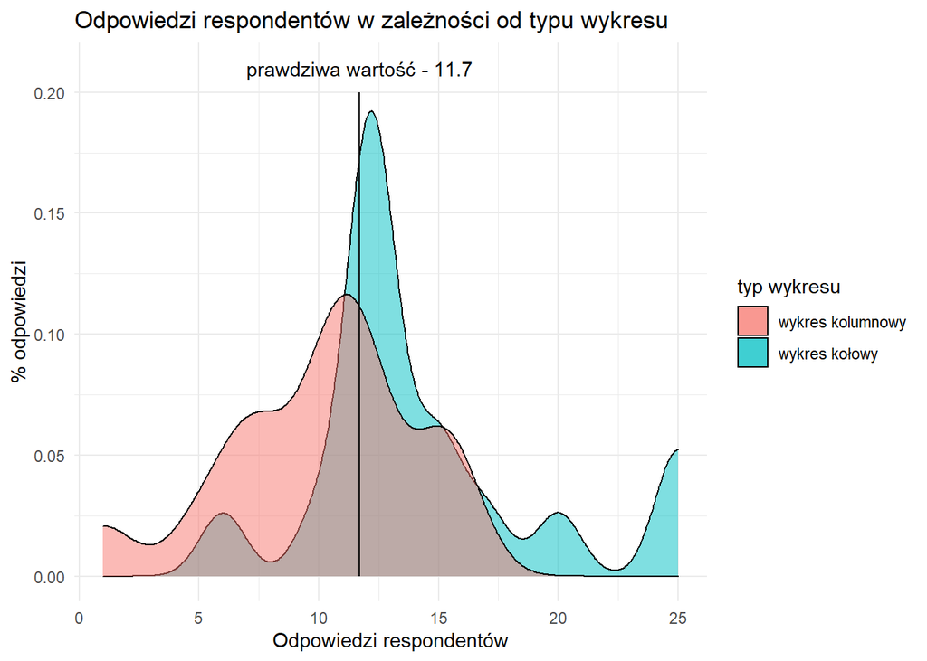

```r
# wczytanie bibliotek
library("ggplot2")
library("dplyr")

# generowanie wykresu wynikow
ans_pie_chart = c(12, 12, 20, 12.3, 12, 12,6, 12, 10, 25, 15.05, 25, 13.37,
                    17, 15, 12.6)
ans_bar_plot = c(15, 8, 15, 9.9, 16, 11.7, 7, 11, 11, NA, 12, 6.9, 1,5, 10,
                   12.5)
df = data.frame(bar_plot = ans_bar_plot, pie_chart = ans_pie_chart)
df %>%
  ggplot() +
  geom_density(aes(x = pie_chart, fill = "wykres kołowy"), adjust= 0.7, alpha = 0.5) +
  geom_density(aes(x = bar_plot, fill = "wykres kolumnowy"), na.rm = TRUE, adjust = 0.7, alpha = 0.5) +
  geom_segment(aes(x = 11.7, y = 0, xend = 11.7, yend = 0.2)) +
  annotate(geom="text", x=11.7, y=0.21, label="prawdziwa wartość - 11.7", color="#000000") +
  labs(fill = "typ wykresu", x = "Odpowiedzi respondentów", y = "% odpowiedzi")+
  ggtitle("Odpowiedzi respondentów w zależności od typu wykresu")+
  theme_minimal()
```

## Wnioski

Jak widać na załączonym wykresie respondenci z reguły niedoszacowywali wartości na wykresie kolumnowym, zaś na wykresie kołowym lekko ją przeszacowywali.